# Hypothesis

Ali Ramezanian Nik

2023-04-28

#DISCLAIMER My machine is an old machine and every training takes 2 nights (because I am using  
my computer during the day doing other assignments). So I used 10000 of data for this assignment.

# Introduction

In this Assignment we want to state some hypothesis and decide on them. In the previous  
article about Exploratory Data Analysis we just clean and explored the data. In this article  
we try to guess some hypothesis and trying to validate them.

But before doing anything let’s look at our data again to review and refresh our mind from our famous dataset:

```r
diamonds <- read.csv("DiamondDataComplete.csv")
summary(diamonds)
```

```
##      carat            cut               color             clarity
##  Min.   :0.2000   Length:50000       Length:50000       Length:50000
##  1st Qu.:0.4000   Class :character   Class :character   Class :character
##  Median :0.7000   Mode  :character   Mode  :character   Mode  :character
##  Mean   :0.7974
##  3rd Qu.:1.0400
##  Max.   :5.0100
##      depth           table           price             x
##  Min.   :43.00   Min.   :43.00   Min.   :  326   Min.   : 0.00
##  1st Qu.:61.00   1st Qu.:56.00   1st Qu.:  949   1st Qu.: 4.71
##  Median :61.80   Median :57.00   Median : 2401   Median : 5.70
##  Mean   :61.75   Mean   :57.45   Mean   : 3925   Mean   : 5.73
##  3rd Qu.:62.50   3rd Qu.:59.00   3rd Qu.: 5312   3rd Qu.: 6.54
##  Max.   :79.00   Max.   :95.00   Max.   :18823   Max.   :10.74
##        y                z
##  Min.   : 0.000   Min.   : 0.000
##  1st Qu.: 4.720   1st Qu.: 2.910
##  Median : 5.710   Median : 3.520
##  Mean   : 5.732   Mean   : 3.538
##  3rd Qu.: 6.540   3rd Qu.: 4.030
##  Max.   :31.800   Max.   :31.800
```

# Hypothesis

In this part we guess two hypothesis and we try to validate them.

## First Hypothesis

```
H0: u >= 3925
H1: u < 3925
```

Now with the information we have lets calculate the hypothesis:

```r
xbar <- 3800
s <- 12
u0 <- 3925
n <- 10
degree_of_freedom <- 10 - 1
t_critical <- -1.833
t_calculated <- (xbar - u0) / (s/sqrt(n))
t_calculated
```

```
## [1] -32.94039
```

The calculated t is not bigger than the critical t and with 95% confidence  
we can not accept the null hypothesis that the average of selected sample is  
above 3925 and we reject NULL hypothesis.

## Second hypothesis

We believe that because Ideal and Premium cuts having almost the same semantic meaning in English and they are almost identical words, so if we randomly select 50 samples from Ideal cuts and 60 samples from Premium cuts with calculated standard deviations that you see below, there should not be any different in the mean of prices with 10% significance level.

here is our hypothesis:

```
h0: u1 == u2  u1-u2 = 0

h1: u1 != u2  u1-u2 != 0
```

```r
ideal_diamonds <- subset(diamonds, cut == "Ideal")
sample_ideal <- sample(ideal_diamonds$price, 50)
sd_ideal <- sd(sample_ideal)
mean_ideal <- mean(sample_ideal)

premium_diamonds <- subset(diamonds, cut == "Premium")
sample_premium <- sample(premium_diamonds$price, 60)
sd_premium <- sd(sample_premium)
mean_premium <- mean(sample_premium)
```

We calculated the standard deviation and now we have all information that is needed to  
to check the hypothesis:

ideal: n = 50, xbar1 = 3690.62, s1 = 4107.78

premium: n = 60, xbar2 = 3116.98, s2 = 3333.36

significance_level = 10% ===> confidence_level = 100% - significance_level = 90% and z(90%) == 1.645 so if z_critial become more than 1.645 or z_critical become less than > -1.645 we should reject the h0 (null hypothesis)

```r
z_critical <- ((mean_ideal-mean_premium) - (0))/sqrt(((sd_ideal*sd_ideal)/50)+((sd_premium*sd_premium)/60))
z_critical
```

```
## [1] 0.7934597
```

# Split data to Train And Test (75% to 25%)

In this part we divde the dataset into two groups: train and test. the train dataset is 75% of total dataset  
and test data set is 25% of total dataset.

```r
trainingInd <- createDataPartition(diamonds$price, p= 0.75, list = F)
training_data <- diamonds[trainingInd,]
test_data <- diamonds[-trainingInd,]
```

# Linear Regression with Multiple Variables and Calculate “adjusted R squared”

Now lets calculate linear regression and adjusted R squared.

```r
linear_mulvar_reg <- lm(price ~ cut+carat + cut + color + clarity + table+x+y+z+depth, data = training_data)
summary(linear_mulvar_reg)
```

```
##
## Call:
## lm(formula = price ~ cut + carat + cut + color + clarity + table +
##     x + y + z + depth, data = training_data)
##
## Residuals:
##      Min       1Q   Median       3Q      Max
## -21291.4   -594.3   -185.4    375.2  10683.0
##
## Coefficients:
##               Estimate Std. Error t value Pr(>|t|)
## (Intercept)   2005.891    488.635   4.105 4.05e-05 ***
## cutGood        577.600     40.183  14.374  < 2e-16 ***
## cutIdeal       836.847     39.884  20.982  < 2e-16 ***
## cutPremium     770.145     38.398  20.057  < 2e-16 ***
## cutVery Good   715.481     38.513  18.578  < 2e-16 ***
## carat        11245.889     58.992 190.635  < 2e-16 ***
## colorE        -198.367     21.589  -9.188  < 2e-16 ***
## colorF        -296.854     21.815 -13.608  < 2e-16 ***
## colorG        -483.393     21.343 -22.648  < 2e-16 ***
## colorH        -983.028     22.686 -43.332  < 2e-16 ***
## colorI       -1472.383     25.514 -57.710  < 2e-16 ***
## colorJ       -2371.768     31.394 -75.548  < 2e-16 ***
## clarityIF     5397.578     61.323  88.018  < 2e-16 ***
## claritySI1    3692.237     52.658  70.118  < 2e-16 ***
## claritySI2    2740.301     52.878  51.823  < 2e-16 ***
## clarityVS1    4602.596     53.767  85.602  < 2e-16 ***
## clarityVS2    4295.842     52.935  81.154  < 2e-16 ***
## clarityVVS1   5056.454     56.959  88.773  < 2e-16 ***
## clarityVVS2   4986.222     55.339  90.103  < 2e-16 ***
## table          -25.051      3.515  -7.127 1.05e-12 ***
## x            -1124.653     49.909 -22.534  < 2e-16 ***
## y              128.937     40.063   3.218  0.00129 **
## z              -51.121     35.107  -1.456  0.14536
## depth          -62.779      5.350 -11.734  < 2e-16 ***
## ---
## Signif. codes:  0 '***' 0.001 '**' 0.01 '*' 0.05 '.' 0.1 ' ' 1
##
## Residual standard error: 1134 on 37478 degrees of freedom
## Multiple R-squared:  0.9193, Adjusted R-squared:  0.9192
## F-statistic: 1.856e+04 on 23 and 37478 DF,  p-value: < 2.2e-16
```

As you can see the “adjusted R squared” is 0.9192 and it is almost near to 1 and  
it means that the variables can explain price very well. Also carat is the best variable we can explain price base on that.

# Test the model

```r
predictions <- predict(linear_mulvar_reg, newdata = test_data)
summary(predictions)
```

```
##    Min. 1st Qu.  Median    Mean 3rd Qu.    Max.
##   -4372    1097    2817    3925    5840   31567
```

```r
RMSE <- sqrt(mean((predictions - test_data$price)^2))
RMSE
```

```
## [1] 1121.712
```

```r
cor(predictions, test_data$price)
```

```
## [1] 0.9589231
```

As you can see the correlation of predicted data and real answer is about 0.95 and  
that means that the model is working well.  
RMSE is a big number and we hope it reduce and be near zero after we normalize dataset.

# Normalization

This time we first normalize dataset with preProcess function and redo previous  
steps to compare correlation and RMSE with previous step correlation and RMSE.

```r
preProcessed <- preProcess(training_data, method = c("center", "scale"))

pre_train <- predict(preProcessed, training_data)
pre_test <- predict(preProcessed, test_data)

pre_linear_mulvar_reg <- lm(price ~ cut+carat + cut + color + clarity + table+x+y+z+depth, data = pre_train)
summary(pre_linear_mulvar_reg)
```

```
##
## Call:
## lm(formula = price ~ cut + carat + cut + color + clarity + table +
##     x + y + z + depth, data = pre_train)
##
## Residuals:
##     Min      1Q  Median      3Q     Max
## -5.3379 -0.1490 -0.0465  0.0941  2.6783
##
## Coefficients:
##               Estimate Std. Error t value Pr(>|t|)
## (Intercept)  -1.041584   0.015129 -68.847  < 2e-16 ***
## cutGood       0.144809   0.010074  14.374  < 2e-16 ***
## cutIdeal      0.209805   0.009999  20.982  < 2e-16 ***
## cutPremium    0.193082   0.009627  20.057  < 2e-16 ***
## cutVery Good  0.179378   0.009656  18.578  < 2e-16 ***
## carat         1.337210   0.007015 190.635  < 2e-16 ***
## colorE       -0.049732   0.005413  -9.188  < 2e-16 ***
## colorF       -0.074424   0.005469 -13.608  < 2e-16 ***
## colorG       -0.121191   0.005351 -22.648  < 2e-16 ***
## colorH       -0.246454   0.005688 -43.332  < 2e-16 ***
## colorI       -0.369140   0.006396 -57.710  < 2e-16 ***
## colorJ       -0.594624   0.007871 -75.548  < 2e-16 ***
## clarityIF     1.353222   0.015374  88.018  < 2e-16 ***
## claritySI1    0.925677   0.013202  70.118  < 2e-16 ***
## claritySI2    0.687018   0.013257  51.823  < 2e-16 ***
## clarityVS1    1.153912   0.013480  85.602  < 2e-16 ***
## clarityVS2    1.077006   0.013271  81.154  < 2e-16 ***
## clarityVVS1   1.267699   0.014280  88.773  < 2e-16 ***
## clarityVVS2   1.250091   0.013874  90.103  < 2e-16 ***
## table        -0.013996   0.001964  -7.127 1.05e-12 ***
## x            -0.316301   0.014036 -22.534  < 2e-16 ***
## y             0.036260   0.011267   3.218  0.00129 **
## z            -0.009095   0.006246  -1.456  0.14536
## depth        -0.022564   0.001923 -11.734  < 2e-16 ***
## ---
## Signif. codes:  0 '***' 0.001 '**' 0.01 '*' 0.05 '.' 0.1 ' ' 1
##
## Residual standard error: 0.2842 on 37478 degrees of freedom
## Multiple R-squared:  0.9193, Adjusted R-squared:  0.9192
## F-statistic: 1.856e+04 on 23 and 37478 DF,  p-value: < 2.2e-16
```

```r
pre_predictions <- predict(pre_linear_mulvar_reg, newdata = pre_test)
summary(pre_predictions)
```

```
##      Min.   1st Qu.    Median      Mean   3rd Qu.      Max.
## -2.081410 -0.710417 -0.279168 -0.001311  0.478663  6.928758
```

```r
pre_RMSE <- sqrt(mean((pre_predictions - pre_test$price)^2))
pre_RMSE
```

```
## [1] 0.2812234
```

```r
cor(pre_predictions, pre_test$price)
```

```
## [1] 0.9589231
```

The difference of this iteration is that the RMSE become much smaller this time and  
changed from 1121.712 to 0.2812234 this time.  
Ideal RMSE is 0 and and we calculated it as 0.2812234. this shows that the test data  
responses are very well. because correlation is near 1 and RMSE is near 0.

# Split data to Train And Test (80% to 20%)

In this part we will use machine learning algorithms to train our models and investigate the  
results.

# kNN

K nearest neighbors is the first machine learning algorithm that we will use it.

```r
s <- sample(nrow(diamonds), size=10000, replace = FALSE, prob = NULL)
di <- diamonds[s, ]

trainingInd <- createDataPartition(di$cut, p= 0.8, list = F)
cut_train <- di[trainingInd,]
cut_test <- di[-trainingInd,]


trainctrl <- trainControl(method = "repeatedcv", number = 5, repeats = 2)
knn_fit <- train(cut ~ ., data = cut_train, method = "knn", trControl = trainctrl, preProcess = c("center", "scale"), tuneLength = 10)
knn_fit
```

```
## k-Nearest Neighbors
##
## 8002 samples
##    9 predictor
##    5 classes: 'Fair', 'Good', 'Ideal', 'Premium', 'Very Good'
##
## Pre-processing: centered (20), scaled (20)
## Resampling: Cross-Validated (5 fold, repeated 2 times)
## Summary of sample sizes: 6400, 6402, 6402, 6401, 6403, 6403, ...
## Resampling results across tuning parameters:
##
##   k   Accuracy   Kappa
##    5  0.5844152  0.3986073
##    7  0.5821662  0.3909594
##    9  0.5782928  0.3824535
##   11  0.5774820  0.3789673
##   13  0.5735448  0.3700336
##   15  0.5662335  0.3563784
##   17  0.5662984  0.3547824
##   19  0.5594238  0.3418473
##   21  0.5572360  0.3364984
##   23  0.5531108  0.3289857
##
## Accuracy was used to select the optimal model using the largest value.
## The final value used for the model was k = 5.
```

```r
knnPredict <- predict(knn_fit, newdata = cut_test )
caret::confusionMatrix(knnPredict, as.factor(cut_test$cut))
```

```
## Confusion Matrix and Statistics
##
##            Reference
## Prediction  Fair Good Ideal Premium Very Good
##   Fair        24    7     0       0         0
##   Good        17   49     3       5        30
##   Ideal        3   25   689     104       158
##   Premium      5   47    58     331       153
##   Very Good   13   52    50      71       104
##
## Overall Statistics
##
##                Accuracy : 0.5991
##                  95% CI : (0.5772, 0.6207)
##     No Information Rate : 0.4004
##     P-Value [Acc > NIR] : < 2.2e-16
##
##                   Kappa : 0.4192
##
##  Mcnemar's Test P-Value : < 2.2e-16
##
## Statistics by Class:
##
##                      Class: Fair Class: Good Class: Ideal Class: Premium
## Sensitivity              0.38710     0.27222       0.8612         0.6477
## Specificity              0.99638     0.96975       0.7579         0.8231
## Pos Pred Value           0.77419     0.47115       0.7038         0.5572
## Neg Pred Value           0.98068     0.93083       0.8911         0.8718
## Prevalence               0.03103     0.09009       0.4004         0.2558
## Detection Rate           0.01201     0.02452       0.3448         0.1657
## Detection Prevalence     0.01552     0.05205       0.4900         0.2973
## Balanced Accuracy        0.69174     0.62098       0.8096         0.7354
##                      Class: Very Good
## Sensitivity                   0.23371
## Specificity                   0.88023
## Pos Pred Value                0.35862
## Neg Pred Value                0.80035
## Prevalence                    0.22272
## Detection Rate                0.05205
## Detection Prevalence          0.14515
## Balanced Accuracy             0.55697
```

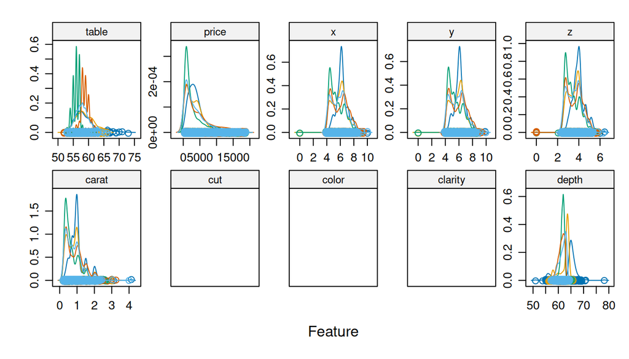

```r
featurePlot(x = cut_train, y = as.factor(cut_train$cut), plot = "density",
            strip=strip.custom(par.strip.text=list(cex=.7)),
            scales = list(x = list(relation="free"), y = list(relation="free")))
```

As you can observe from confusion matrix, Ideal and Premium cuts has the best sensitivity rate,  
and we can conclude by observing featurePlot that the most effective feature in classification is  
the table of a diamond because the table plot has the most distinct curves and we can guess that the  
two most distinct curves are Ideal and Premium curves.